# STAT 385 Statistics Programming Methods - Fall 2020

## Week 12 Notes

### Created by Christopher Kinson

## Things Covered in this Week’s Notes

- Data visualization in R (base R)
- Data visualization in R (ggplot2 in the tidyverse)
- Visual design principles

Plots, graphs, and visual charts are the most crucial tools we have as data analysts, statisticians, and data scientists. In the notes that follow, I will highlight base R plotting and ggplot2 (the tidyverse) plotting capabilities. Consider these notes as a reference for what’s possible in R for data visualization.

## Data visualization in R (base R)

The `plot` function in R is quite powerful and flexible. We explain by example but first, let’s import a version of the jail Jail Data by importing with the tidyverse’s `read_csv()`.

```r
library(tidyverse)
jail <- read_csv("https://uofi.box.com/shared/static/9elozjsg99bgcb7gb546wlfr3r2gc9b7.csv")
jail$`days in jail` <- as.numeric(jail$`Days in Jail`)
jail$`hours in jail` <- as.numeric(jail$Hours)
jail$`minutes in jail` <- as.numeric(jail$Minutes)
jail$`seconds in jail` <- as.numeric(jail$Seconds)
jail <- jail[sample(nrow(jail),200),-c(31:35)]
colnames(jail) <- tolower(colnames(jail))
jail$race2 <- ifelse(jail$race=="Black","Black","Not Black")
```

Typically we plot two numeric vectors.

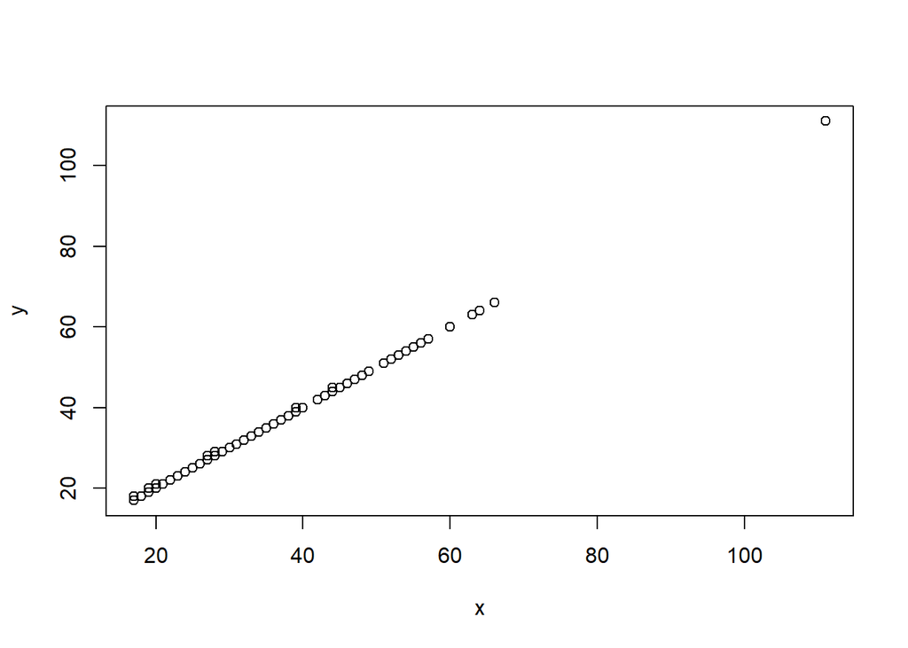

```r
x<- jail$`age at arrest`
y<- jail$`age at release`
plot(x,y)
```

The two numeric vectors could be in a single matrix.

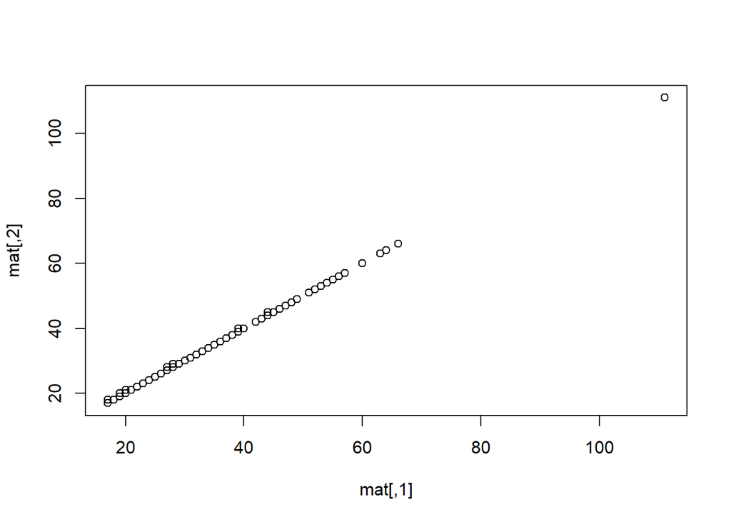

```r
mat<- matrix(c(jail$`age at arrest`,jail$`age at release`), ncol=2)
plot(mat)
```

We could create a time series plot (aka “index plot” aka “series plot”) using a single numeric vector.

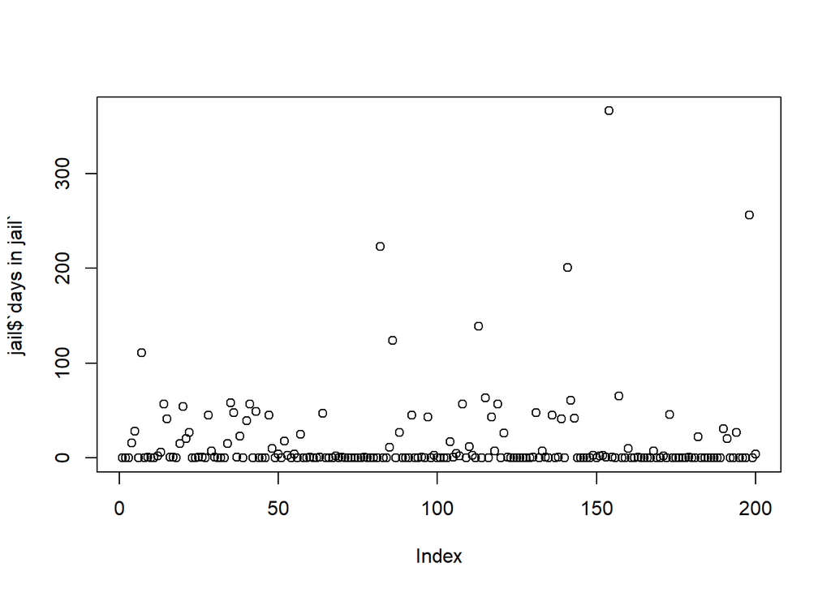

```r
plot(jail$`days in jail`)
```

We could take advantage of factors in the data to plot a bar plot or box plots per level of the factor.

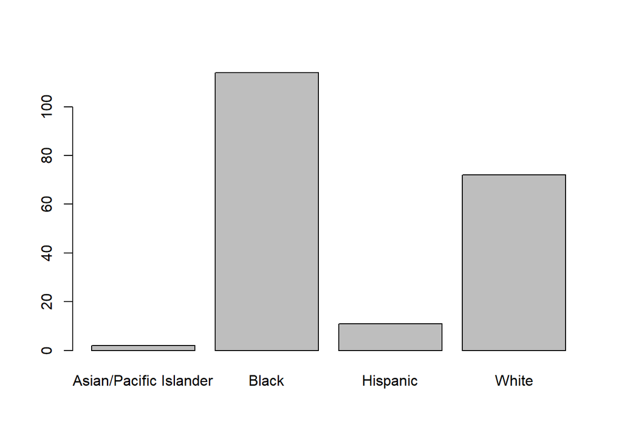

```r
jr<-factor(jail$race)
plot(jr)
```

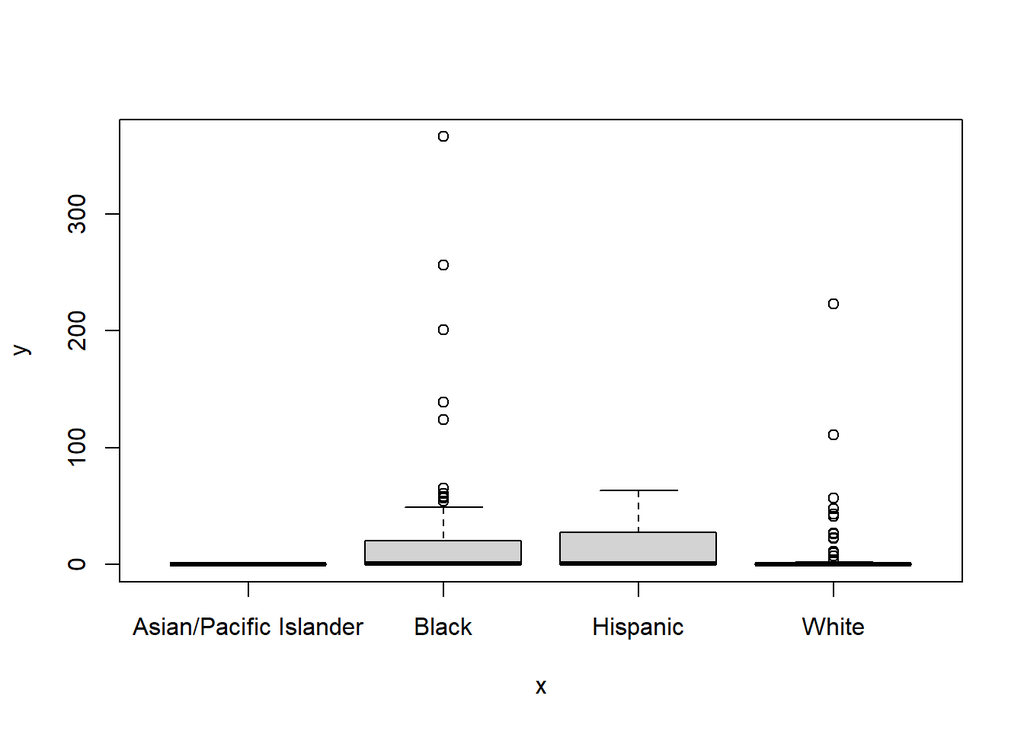

```r
plot(jr, jail$`days in jail`)
```

Or we could use the `table` function to explicitly count the frequency for the levels or categories to show a bar plot with `barplot()`.

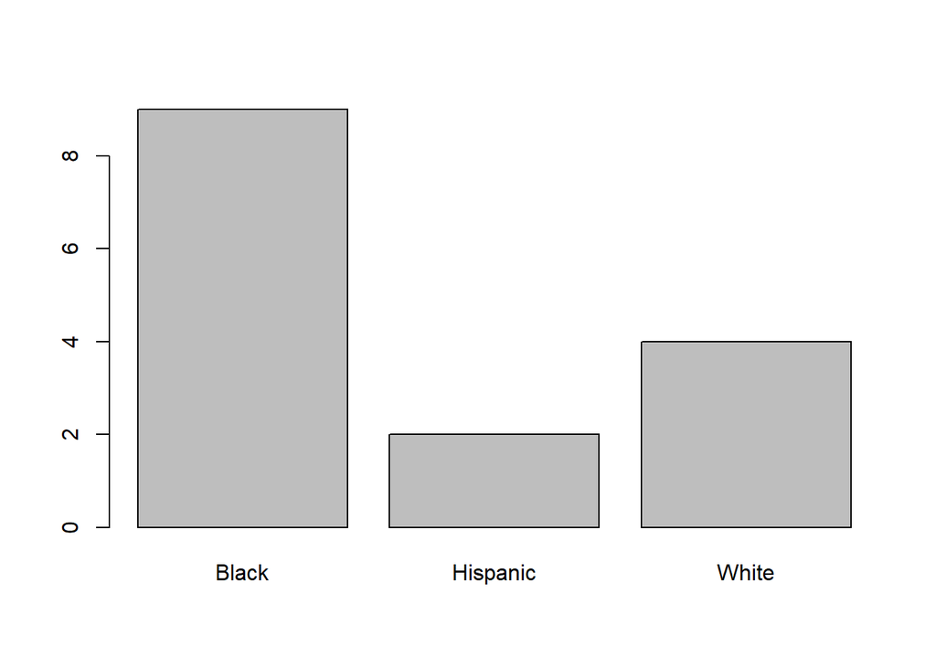

```r
ccs <- names(sort(table(jail$`crime code`), decreasing=TRUE)[1:5])
jcc <- jail[which(jail$`crime code`==ccs),]
t1 <- table(jcc$`crime code`, jcc$race)

barplot(colSums(t1))
```

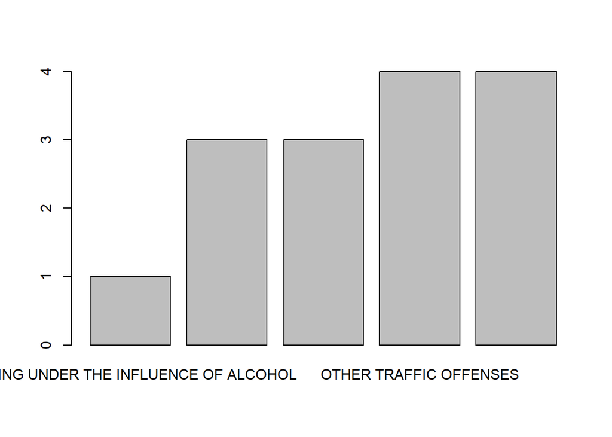

```r
barplot(rowSums(t1))
```

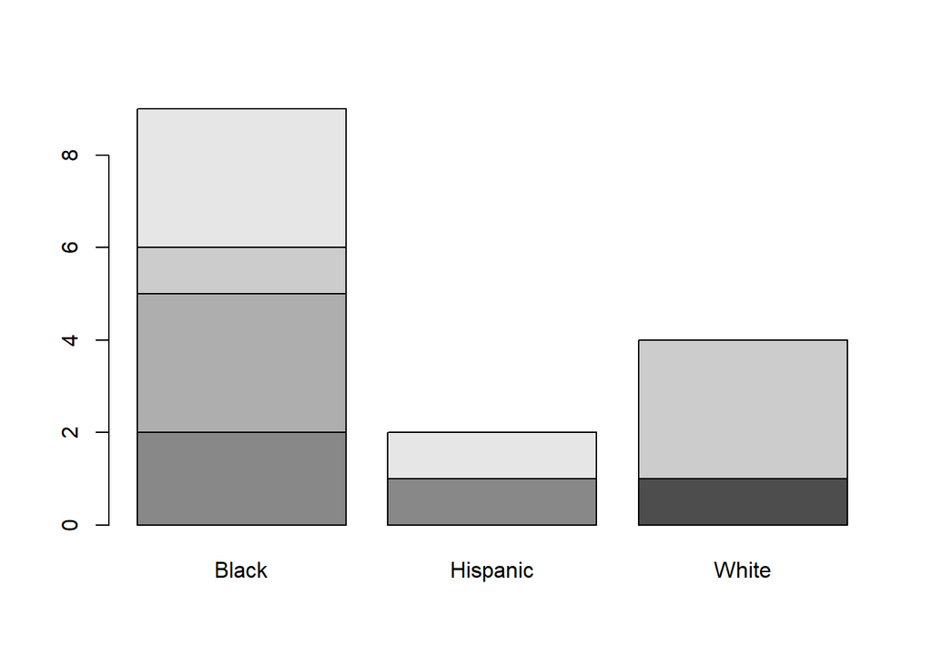

```r
barplot(t1)
```

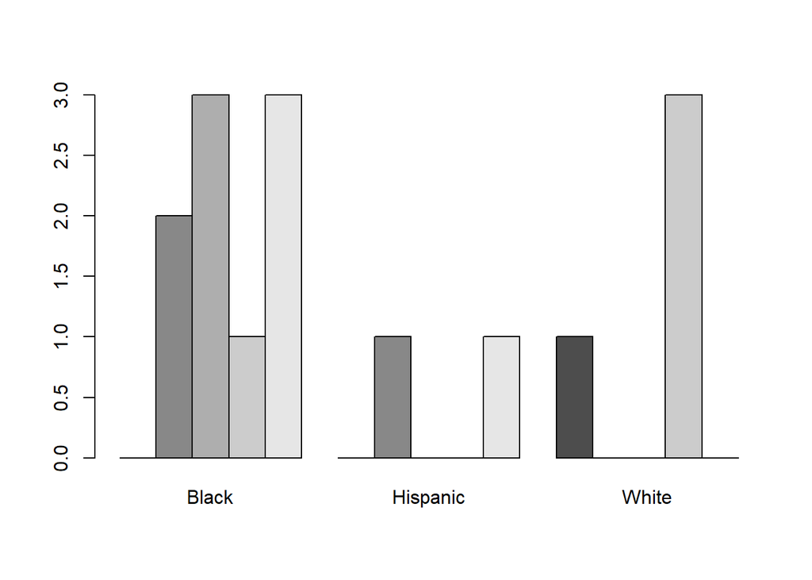

```r
barplot(t1, beside = TRUE)
```

We can create univariate visualizations such as a histogram.

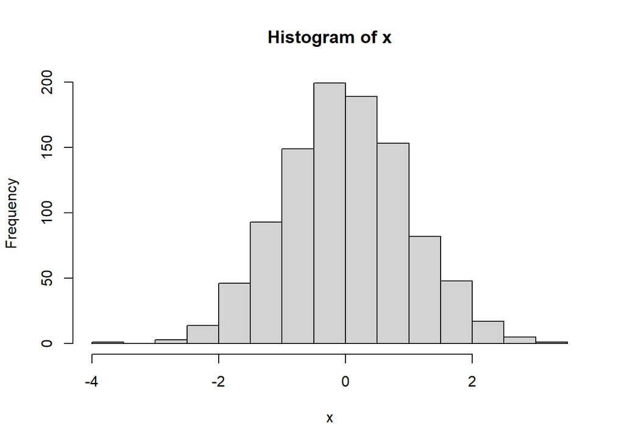

```r
x <- rnorm(1000)
hist(x)
```

Q-Q plot (AKA quantile-quantile plot AKA normal scores plot).

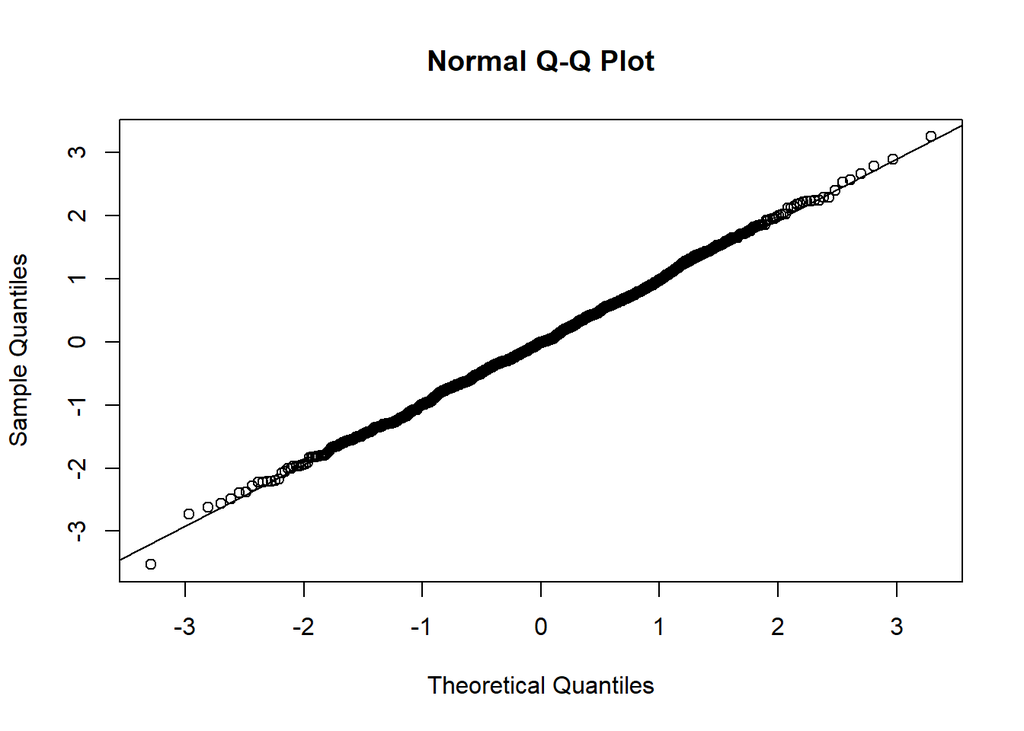

```r
qqnorm(x)
qqline(x) #adds a reference line based on theoretical values
```

For data frames, we can leverage that structure to produce multiple plots with one `plot()` function.

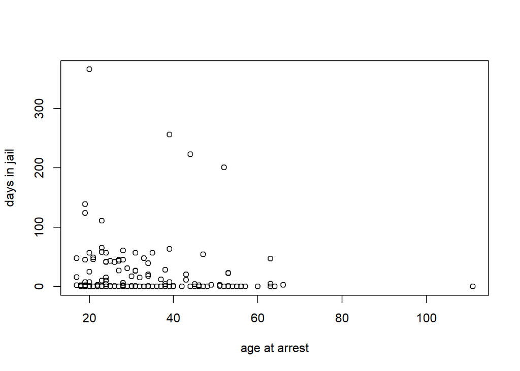

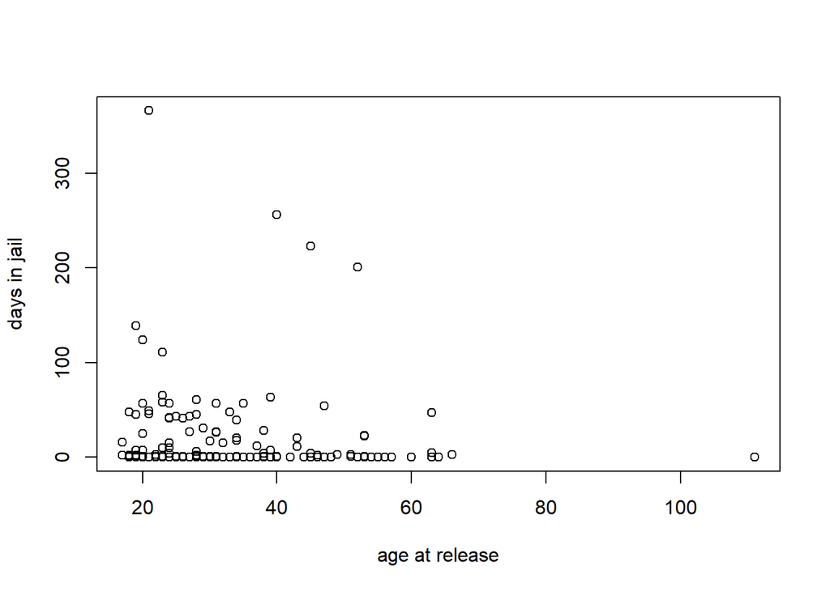

```r
plot(`days in jail` ~ `age at arrest` + `age at release`, data=jail)
```

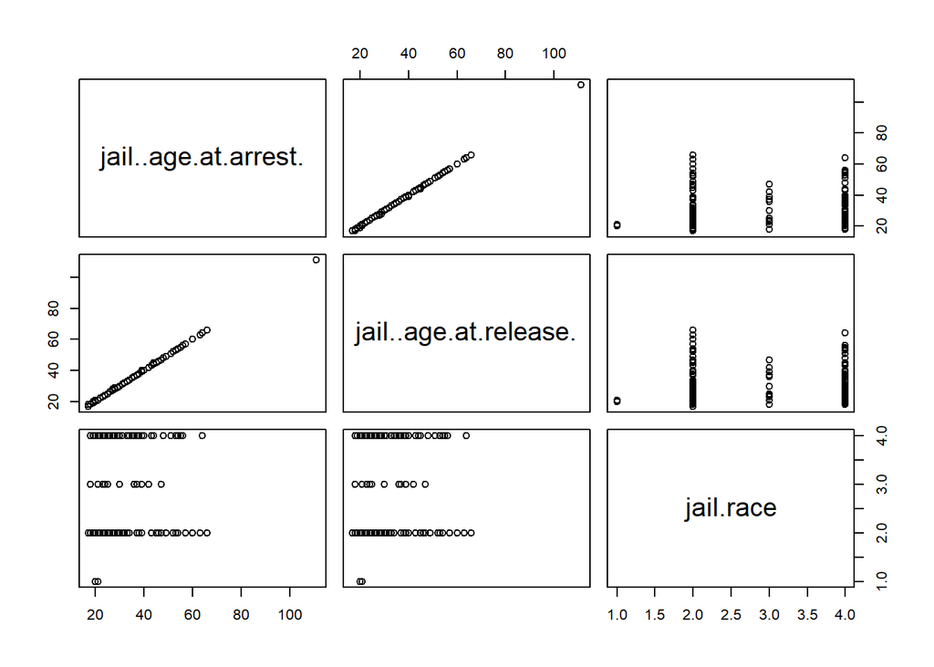

```r
jdf<-data.frame(jail$`age at arrest`, jail$`age at release`, jail$race)
plot(jdf)
```

One popular multivariate plot is with the `pairs()` function.

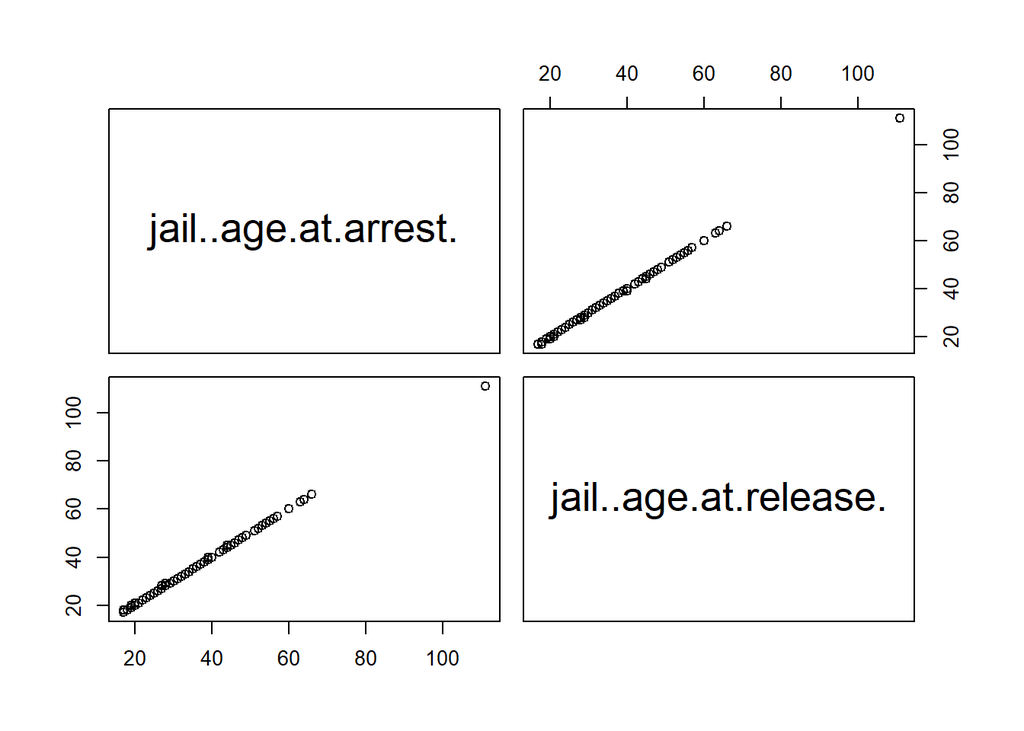

```r
pairs(jdf[,-3])
```

But if we wanted to see the pairwise relationship between age at arrest and days in jail for each racial category (assuming we only had black and white categories), we could use a `coplot()`.

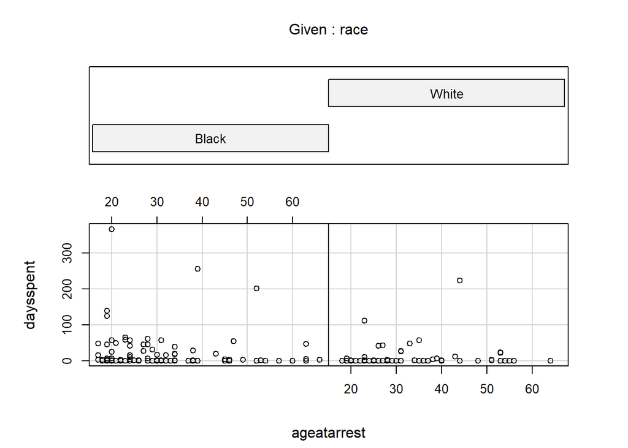

```r
jdff <- data.frame(ageatarrest=jail$`age at arrest`, daysspent=jail$`days in jail`, race=jail$race)
jdff<-jdff[which(jdff$race=="Black" | jdff$race=="White"),]
jdff$race<-factor(jdff$race)
coplot(daysspent ~ ageatarrest | race, data=jdff)
```

We can visualize other multivariate relationships as a mosaic plot with `mosaicplot()`.

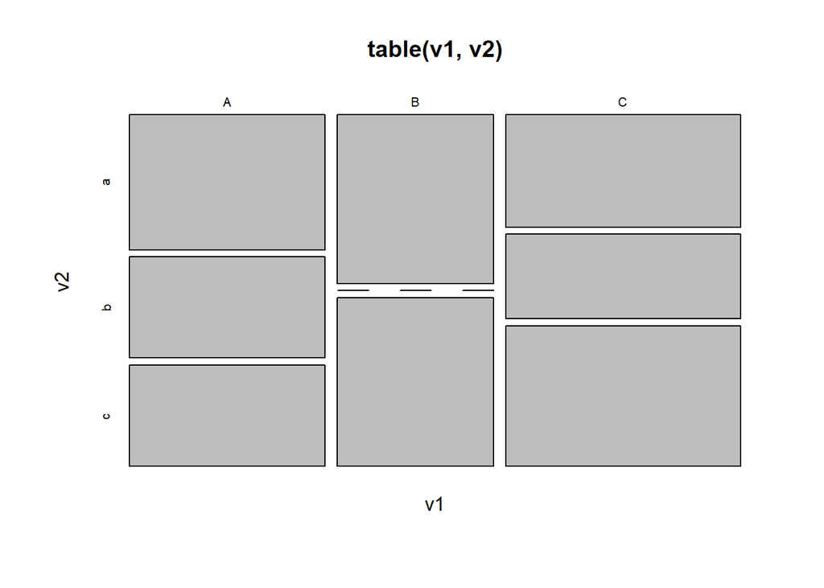

```r
v1<-sample(LETTERS[1:3],30,replace=TRUE)
v2<-sample(letters[1:3],30,replace=TRUE)
mosaicplot(table(v1,v2))
```

Above, we saw various types of plots: scatter, bar plot, series plots, coplots, and pairwise plots. Now let’s specific changes and options we have to get more detailed plotting.

### Adding Plotting Arguments

There are various arguments that can be added to plots to add visual clarity and to remove things that are distracting. Here’s a short list.

- type: changes the plotting type
- xlab: labels the x axis
- ylab: labels the y axis
- main: labels the main title of the plot (appears at the top of the plotting space)
- sub: labels the subtitle of the plot (appears at the bottom of the plotting space)
- pch: changes the plotting character for the point type
- pwd: changes the plotting character width for the point type
- lty: changes the plotting character for the line type
- lwd: changes the plotting character width for the line type
- xlim: adjusts the lower and upper boundaries of the x axis
- ylim: adjusts the lower and upper boundaries of the y axis
- col: changes the colors of the plotting character

Now let’s go back and add basic arguments that may help improve our interpretation of the plots.

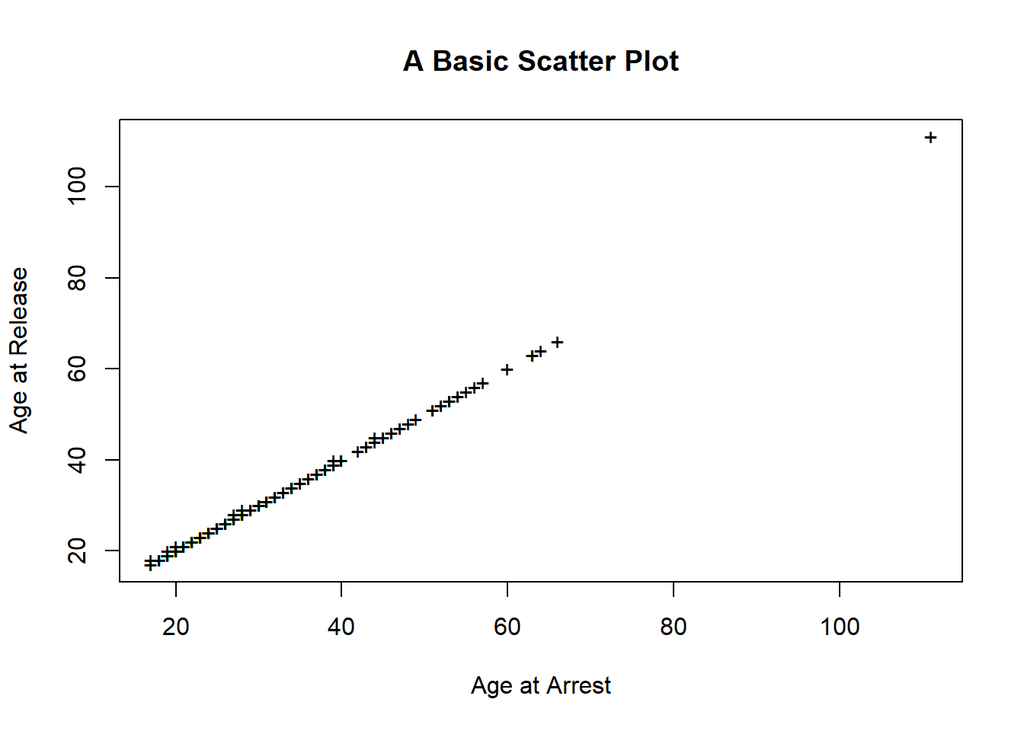

```r
plot(mat, xlab="Age at Arrest", ylab="Age at Release", main="A Basic Scatter Plot", pch="+")
```

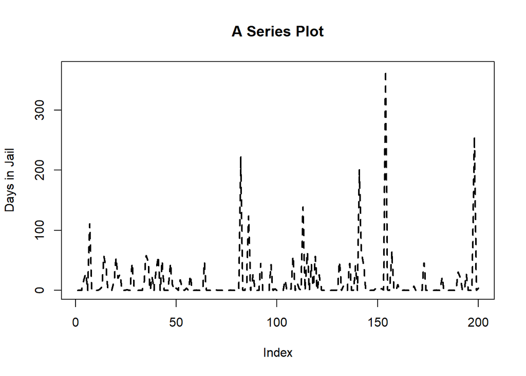

```r
plot(jail$`days in jail`, xlab="Index", ylab="Days in Jail", main="A Series Plot", type="l", lty=2, lwd=2)
```

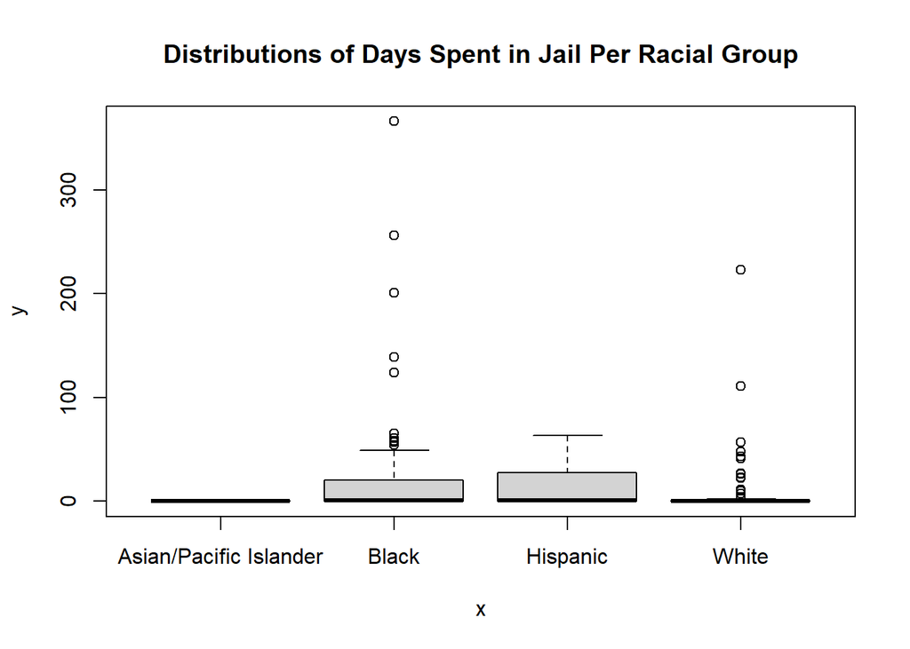

```r
plot(jr, jail$`days in jail`, main="Distributions of Days Spent in Jail Per Racial Group")
```

### Color options

We have a few ways to specify colors of plotting characters and elements. We can specify the colors using a color in quotes, such as “red”, based on the possible colors list using the function `colors()`.

```r
head(colors())
```

```
## [1] "white"         "aliceblue"     "antiquewhite"  "antiquewhite1"
## [5] "antiquewhite2" "antiquewhite3"
```

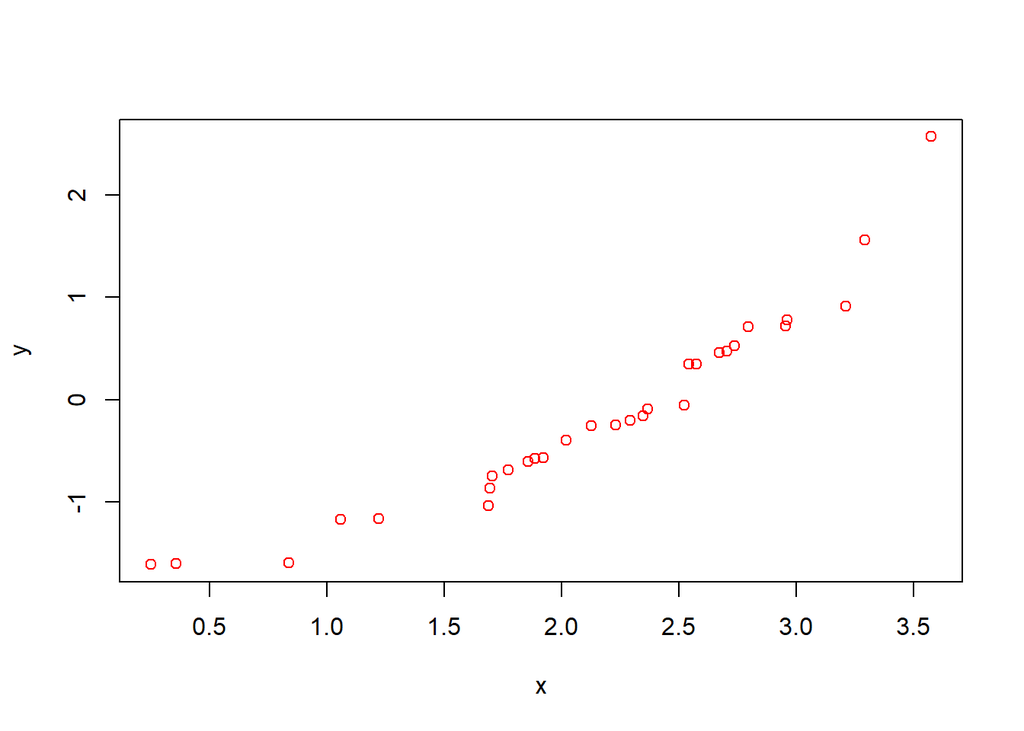

```r
x <- sort(rnorm(30)+2)
y <- sort(rnorm(30))
plot(x, y, col="red")
```

We can use a number for the colors which is a specific short set of colors (1 to 8). These colors come from the `palette()` function.

```r
palette()
```

```
## [1] "black"   "#DF536B" "#61D04F" "#2297E6" "#28E2E5" "#CD0BBC" "#F5C710"
## [8] "gray62"
```

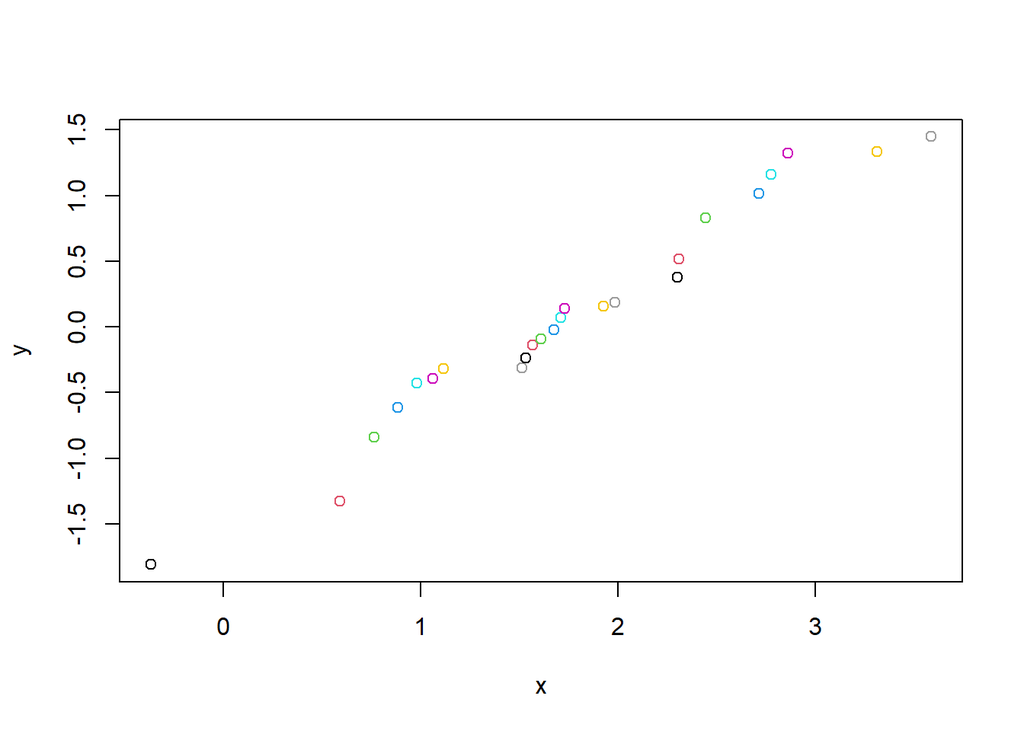

```r
x <- sort(rnorm(24)+2)
y <- sort(rnorm(24))
plot(x, y, col=1:8)
```

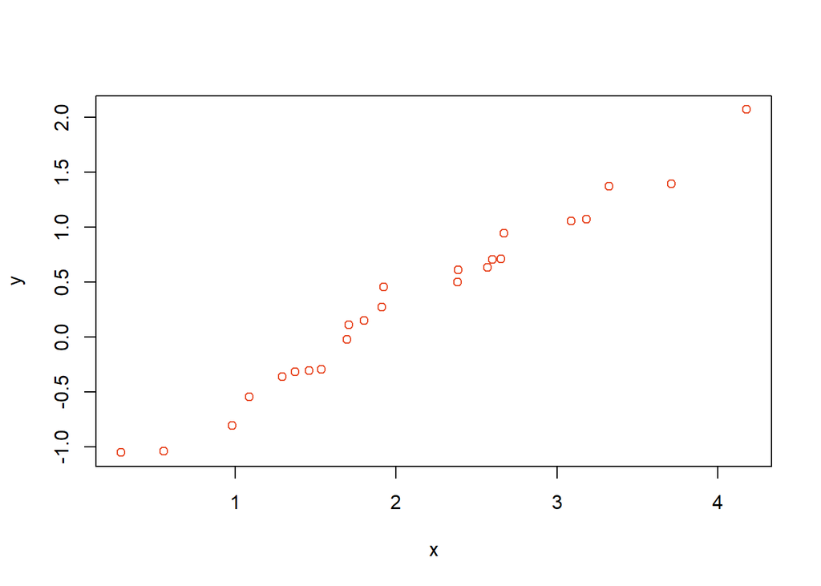

```r
x <- sort(rnorm(24)+2)
y <- sort(rnorm(24))
plot(x, y, col=rgb(232/255,74/255,39/255)) #Illinois orange
```

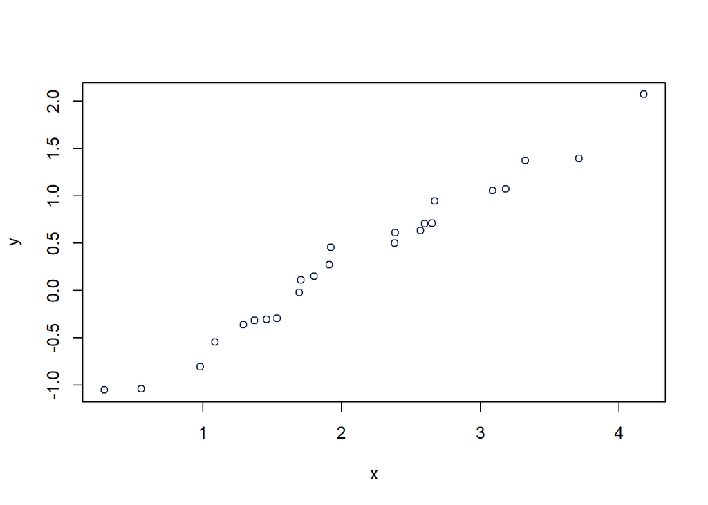

```r
plot(x, y, col="#13294B") #Illinois blue
```

### Jittering points

Sometimes we may have data that is overplotted, i.e. points are on top of each other. We can add a small error (AKA noise AKA perturbation) that would shift the locations of the points so that more of them can be seen.

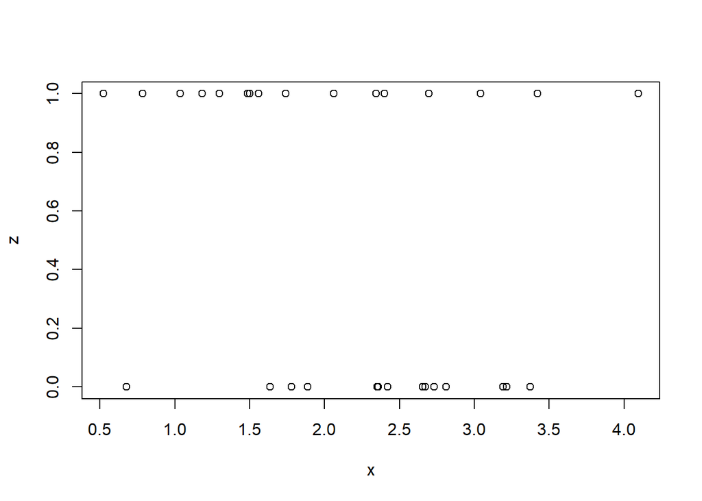

```r
x <- sort(rnorm(30)+2)
y <- sort(rnorm(30))
z <- round(runif(30,0,1))
plot(x,z)
```

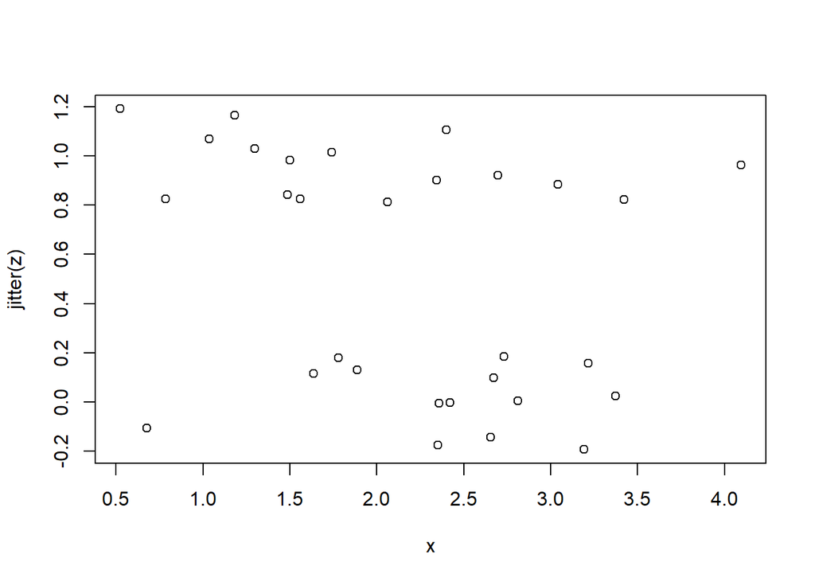

```r
plot(x,jitter(z))
```

### Adding reference lines in plots

Adding **reference lines** is a useful thing to do because it steadies the viewer’s focus. We can add lines to various types of plots with the `lines` function

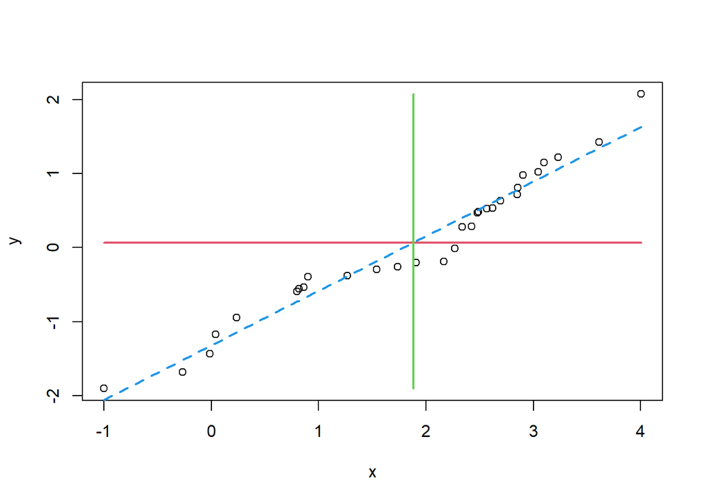

```r
x <- sort(rnorm(30)+2)
y <- sort(rnorm(30))
lm1 <- lm(y ~ x)

plot(x,y)
lines(x,lm1$fitted.values, col=4, lwd=2, lty=2) #a regression line
lines(x,rep(mean(y),length(y)), col=2, lwd=2) # a horizontal line at the mean of y
lines(rep(mean(x),length(x)),y, col=3, lwd=2) # a vertical line at the mean of x
```

### Suppressing plot elements in order to add elements

Sometimes we may want to **suppress** the plotting characters (using the `type="n"` argument inside the plot function) or suppress the axes (using the argument `axes=FALSE` inside the plot function), or suppress framing of the plot (using the `argument frame.plot=FALSE` inside the plot function).

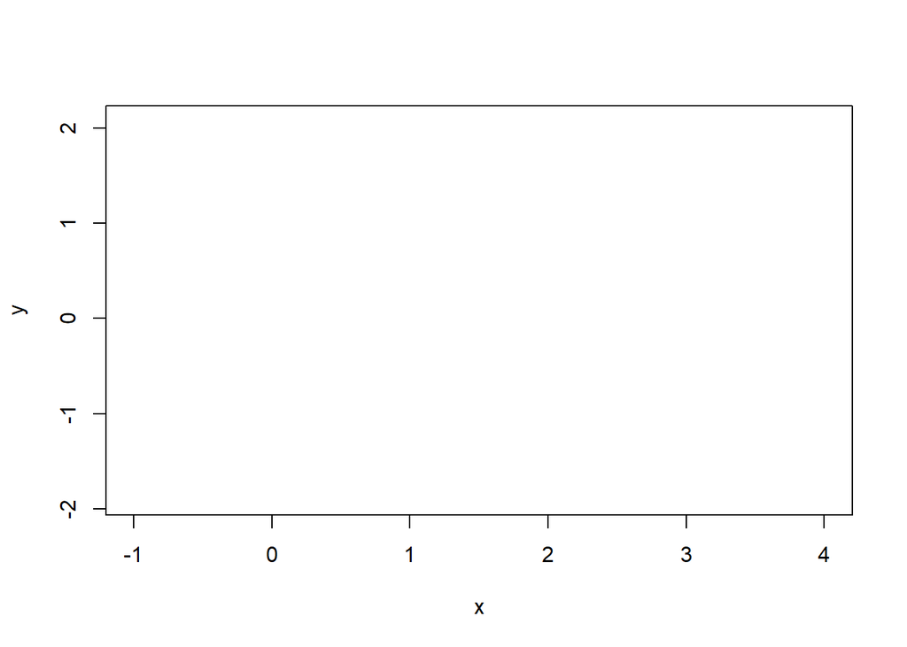

```r
mat <- matrix(runif(30*5), ncol=5 )
plot(x, y, type="n")
```

```r
plot(x, y, type="n", axes=FALSE)
```

[output not shown]

```r
plot(x, y, type="n", axes=FALSE, frame.plot=FALSE)
```

[output not shown]

After suppressing those items, we can **add** a more precise set of characters, such as a loop of points with the `points()` function

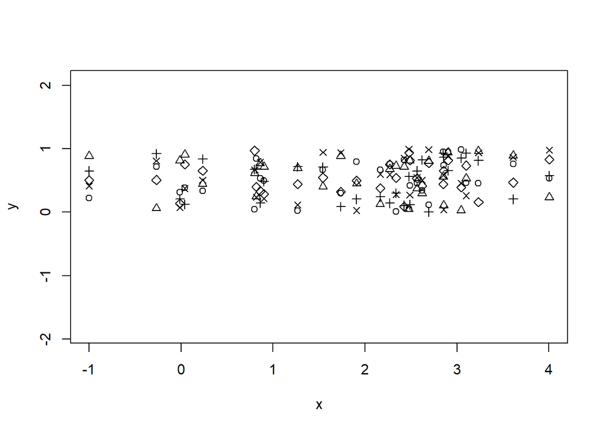

```r
mat <- matrix(runif(30*5), ncol=5 )
plot(x, y, type="n")
for(i in 1:ncol(mat))
  points(x,mat[,i], pch=i)
```

or a loop of lines with the `lines()` function

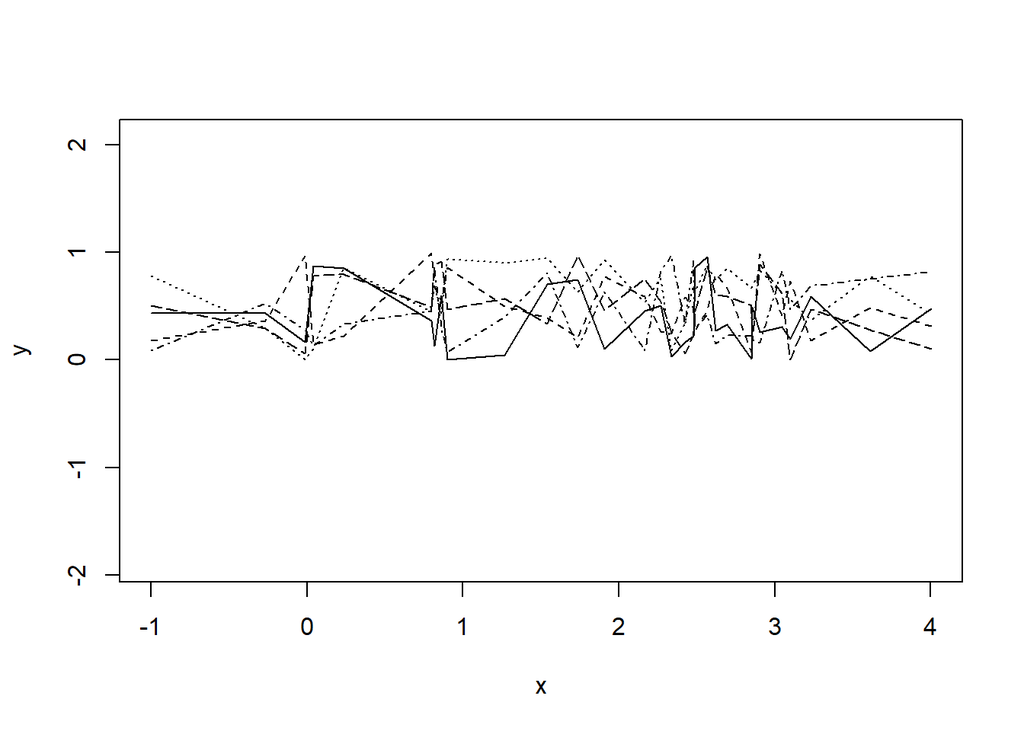

```r
mat <- matrix(runif(30*5), ncol=5 )
plot(x, y, type="n")
for(i in 1:ncol(mat))
  lines(x,mat[,i], lty=i)
```

or a set of text with the `text()` function

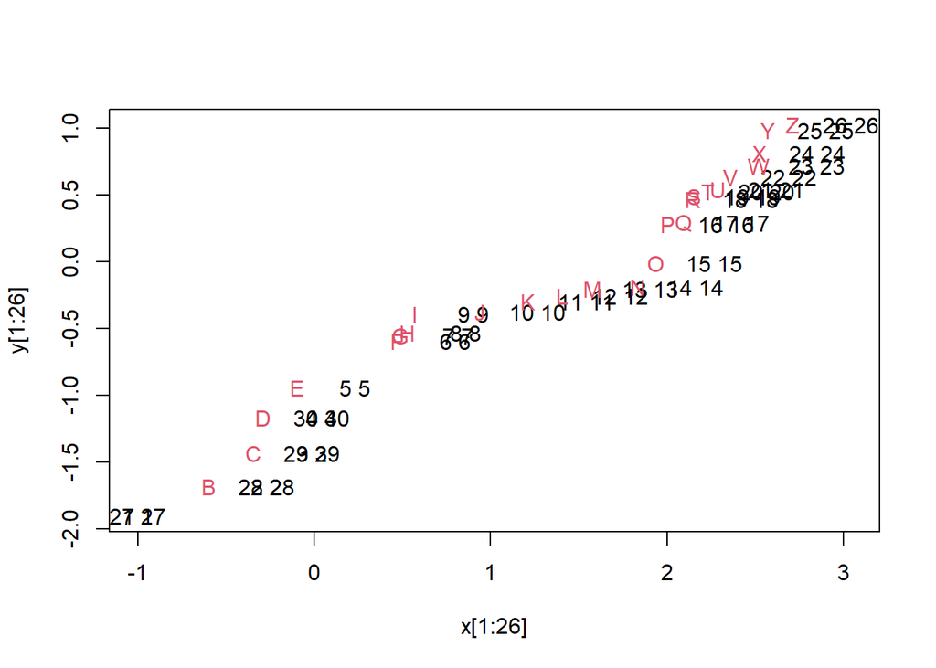

```r
plot(x[1:26], y[1:26], type="n")
text(x[1:26], y[1:26], labels=paste(which(x==x),which(y==y)))
text(x[1:26]-0.33, y[1:26], labels=LETTERS, col= 2)
```